# Sistema Masa-Resorte

Consideramos una sola masa $m$ que puede desplazarse solo a lo largo de una línea horizontal (eje $x$). Denotamos por $x(t)$ la posición del centro de masas y por $x^*$ su posición de equilibrio (punto donde la fuerza neta es cero). Usualmente identificamos a $x^*$ con el cero por simplicidad.

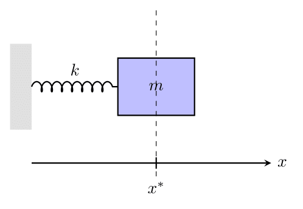

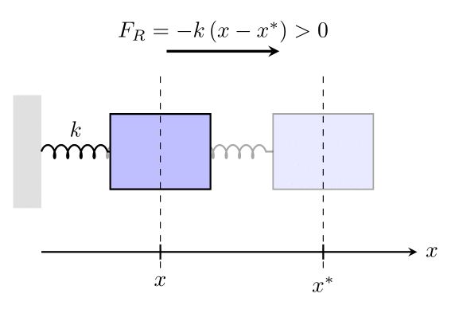

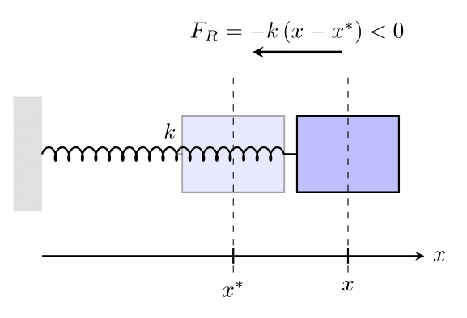

La [segunda ley de Newton](https://en.wikipedia.org/wiki/Newton%27s_laws_of_motion) nos dice que esta misma fuerza es el producto entre la masa de y la aceleración. $$ F=m x''(t) $$

Juntando las dos leyes tenemos la ecuación resultante $$ m x''(t)=-k x(t) $$

Hacemos el cambio de variable **$v(t)=x'(t)$**. Entonces la ecuación $$ m\,x''(t)=-k\,x(t) $$ se escribe como un **sistema lineal de primer orden**:

$$ \begin{cases} x'(t) = v(t),\\[4pt] v'(t) = -\dfrac{k}{m}\,x(t). \end{cases} $$

Con condiciones iniciales $x(0)=x_0$ y $v(0)=v_0$.

En forma matricial, con $y(t)=\begin{pmatrix}x(t)\\ v(t)\end{pmatrix}$, $$ y'(t)=A\,y(t), \qquad A=\begin{pmatrix} 0 & 1\\[2pt] -\dfrac{k}{m} & 0 \end{pmatrix}. $$

Si definimos $\omega=\sqrt{\dfrac{k}{m}}$, el sistema queda $$ \begin{cases} x'(t) = v(t),\\[4pt] v'(t) = -\omega^{2}\,x(t), \end{cases} \qquad A=\begin{pmatrix}0&1\\ -\omega^2&0\end{pmatrix}. $$

Para el sistema $$ y'(t)=A\,y(t), \qquad A=\begin{pmatrix}0&1\\ -\omega^2&0\end{pmatrix}, \quad \omega^2=\frac{k}{m}>0, $$ el **polinomio característico** en dimensión 2 puede escribirse en función de la **traza** $\tau=\operatorname{tr}(A)$ y el **determinante** $\Delta=\det(A)$: $$ p(\lambda)=\lambda^2-\tau\,\lambda+\Delta. $$

En nuestro caso $$ \tau=\operatorname{tr}(A)=0,\qquad \Delta=\det(A)=\omega^2>0, $$ y por tanto $$ p(\lambda)=\lambda^2+\omega^2=0 \;\;\Longrightarrow\;\; \lambda_{1,2}=\pm i\,\omega. $$

Como la **traza** es la suma de los valores propios ($\lambda_1+\lambda_2=\tau=0$) y el **determinante** es su producto ($\lambda_1\lambda_2=\Delta=\omega^2$), obtenemos dos autovalores **puramente imaginarios** y conjugados.

Con $\Delta>0$ y $\tau=0$ se tiene un **centro**. El origen es **estable en el sentido de Lyapunov** (órbitas cerradas periódicas), pero **no asintóticamente estable** (no hay decaimiento, al no existir rozamiento). En este sistema lineal, la linealización coincide con el sistema completo, así que la clasificación es global.

Para sistemas lineales con **valores propios** $\lambda_i$ y **vectores propios** $v_i$, la solución general es una **combinación lineal de exponenciales** dela forma: $$ y(t)=\sum_i c_i\,e^{\lambda_i t}\,v_i. $$

Para obtenes los vectores propios buscamos $A v=\lambda v$. Si $v=(a,b)^\top$, entonces $$ \begin{pmatrix}0&1\\ -\omega^2&0\end{pmatrix}\!\begin{pmatrix}a\\ b\end{pmatrix} =\begin{pmatrix}b\\ -\omega^2 a\end{pmatrix} =\lambda\begin{pmatrix}a\\ b\end{pmatrix} \Longrightarrow \begin{cases} b=\lambda a,\\ -\omega^2 a=\lambda b=\lambda^2 a. \end{cases} $$

Entonces si $a=1$

$$ v_1=\begin{pmatrix}1\\ i\omega\end{pmatrix},\qquad v_2=\begin{pmatrix}1\\ -i\omega\end{pmatrix}. $$

Entonces la Solución general está dada por $$ y(t)=c_1 e^{i\omega t}\begin{pmatrix}1\\ i\omega\end{pmatrix} + c_2 e^{-i\omega t}\begin{pmatrix}1\\ -i\omega\end{pmatrix}. $$ Su primera componente es $$ x(t)=c_1 e^{i\omega t}+c_2 e^{-i\omega t},\qquad v(t)=x'(t)=i\omega c_1 e^{i\omega t}-i\omega c_2 e^{-i\omega t}. $$ Con $x(0)=x_0$, $v(0)=v_0$: $$ c_1+c_2=x_0,\qquad i\omega(c_1-c_2)=v_0 \;\Rightarrow\; c_1=\frac{1}{2}\!\left(x_0-\frac{i v_0}{\omega}\right),\; c_2=\frac{1}{2}\!\left(x_0+\frac{i v_0}{\omega}\right). $$

Usamos las identidades de Euler $$ \cos\theta=\frac{e^{i\theta}+e^{-i\theta}}{2},\qquad \sin\theta=\frac{e^{i\theta}-e^{-i\theta}}{2i}. $$

**Para $x(t)$:** $$ \begin{aligned} x(t) &=\frac{x_0}{2}\bigl(e^{i\omega t}+e^{-i\omega t}\bigr) +\frac{1}{2}\!\left(-\frac{i v_0}{\omega}e^{i\omega t} +\frac{i v_0}{\omega}e^{-i\omega t}\right)\\[2mm] &=x_0\cos(\omega t) +\frac{v_0}{\omega}\,\frac{e^{i\omega t}-e^{-i\omega t}}{2i}\\[1mm] &=\boxed{\,x_0\cos(\omega t)+\dfrac{v_0}{\omega}\sin(\omega t)\,}. \end{aligned} $$

**Para $v(t)$:** $$ \begin{aligned} v(t) &=i\omega\left[\frac12\!\left(x_0-\frac{i v_0}{\omega}\right)e^{i\omega t} -\frac12\!\left(x_0+\frac{i v_0}{\omega}\right)e^{-i\omega t}\right]\\[2mm] &=\frac{i\omega x_0}{2}\bigl(e^{i\omega t}-e^{-i\omega t}\bigr) +\frac{v_0}{2}\bigl(e^{i\omega t}+e^{-i\omega t}\bigr)\\[2mm] &=-\omega x_0\,\frac{e^{i\omega t}-e^{-i\omega t}}{2i} +v_0\,\frac{e^{i\omega t}+e^{-i\omega t}}{2}\\[1mm] &=\boxed{\, -\omega x_0\sin(\omega t)+v_0\cos(\omega t)\,}. \end{aligned} $$

Observa que, como $c_2=\overline{c_1}$ cuando $x_0,v_0\in\mathbb{R}$, la combinación $c_1 e^{i\omega t}+c_2 e^{-i\omega t}$ es real para todo $t$, y las fórmulas obtenidas son la **solución física real**.

$$ \boxed{\,x(t)=x_0\cos(\omega t)+\frac{v_0}{\omega}\,\sin(\omega t)\,},\qquad \boxed{\,v(t)=-\omega x_0\sin(\omega t)+v_0\cos(\omega t)\,}. $$

## Ejercicio

- Grafica la posición del resorte en el plano $t$ vs $x$
- Grafica el plano fase
- ¿Qué sucede si $x_0=0$?
- ¿Qué sucede si $v_0>0$?
- ¿Qué interpretación tiene si $v<0$?

## Fuerza de rozamiento

Si consideramos una **fuerza de rozamiento** $F_r$ (p. ej., fricción con el medio o con la superficie), el modelo más simple y habitual para velocidades moderadas es el **rozamiento viscoso lineal**, proporcional y opuesto a la velocidad: $$ F_r=-c\,x'(t),\qquad c>0. $$ Si el **equilibrio está en el origen** ($x^*=0$) y modelamos el **rozamiento viscoso lineal**, la ecuación del movimiento (sin fuerzas externas) es $$ m\,x''(t)+c\,x'(t)+k\,x(t)=0, \qquad m>0,\;c\ge 0,\;k>0. $$

En variables de primer orden ($v=x'$) el sistema lineal es $$ \begin{cases} x'(t)=v(t),\\[2pt] v'(t)=-\dfrac{c}{m}\,v(t)-\dfrac{k}{m}\,x(t), \end{cases} \qquad A=\begin{pmatrix} 0 & 1\\[2pt] -\dfrac{k}{m} & -\dfrac{c}{m} \end{pmatrix}. $$

Calculamos:

- **Traza** $$ \operatorname{tr}(A)=-\frac{c}{m}. $$
- **Determinante** $$ \det(A)=\frac{k}{m}. $$

Recordemos que, en dimensión $2$, el **polinomio característico** se escribe con traza y determinante como $$ p(\lambda)=\lambda^{2}-\operatorname{tr}(A)\,\lambda+\det(A). $$ Por tanto, $$ \lambda^{2}-\Bigl(-\frac{c}{m}\Bigr)\lambda+\frac{k}{m}=0 \;\Longrightarrow\; \boxed{\;\lambda^{2}+\frac{c}{m}\,\lambda+\frac{k}{m}=0\;}. $$

Aplicando la fórmula cuadrática, $$ \lambda_{1,2} =\frac{-\dfrac{c}{m}\pm\sqrt{\left(\dfrac{c}{m}\right)^{2}-4\,\dfrac{k}{m}}}{2} =-\frac{c}{2m}\pm\sqrt{\left(\frac{c}{2m}\right)^{2}-\frac{k}{m}}. $$

Para simplificar la notación, definimos $$ \alpha=\frac{c}{2m}, \qquad \omega_0=\sqrt{\frac{k}{m}}. $$ Entonces $$ \boxed{\;\lambda_{1,2}=-\alpha\pm\sqrt{\alpha^{2}-\omega_0^{2}}\;} $$

y se obtienen los tres regímenes habituales:

- **Subamortiguado**: $\alpha^{2}-\omega_0^{2}<0$,  
  $\lambda_{1,2}=-\alpha\pm i\,\omega_d$ con $\omega_d=\sqrt{\omega_0^{2}-\alpha^{2}}$.
- **Amortiguamiento crítico**: $\alpha^{2}-\omega_0^{2}=0$,  
  $\lambda_1=\lambda_2=-\alpha$.
- **Sobreamortiguado**: $\alpha^{2}-\omega_0^{2}>0$,  
  $\lambda_{1,2}\in\mathbb{R}$, distintas y negativas.

## Ejercicio

- Grafica la posición del resorte en el plano $t$ vs $x$ en los tres casos
- Da una interpretación del fenómeno en los tres casos
- Identifica los casos en el [video](https://www.youtube.com/watch?v=FgixmWqCwxM) e identificalos. Argumenta tus respuestas

# ¿Por qué necesitamos métodos numéricos?

## Fuerza externa

Si además existe una **fuerza externa** $f(t)$, el modelo estándar es $$ m\,x''+c\,x'+k\,x=f(t). $$

## Fuerza de restitución de orden superior

- Si consideramos un **resorte** con ley de restitución aproximada por el **desarrollo de Taylor** alrededor del equilibrio y truncada en segundo orden: $$ F(x)=-k\,x+\varepsilon\,x^{2},\qquad 0<\varepsilon\ll 1. $$ Entonces la ecuación de movimiento queda como: $$ m\,x''+c\,x'+k\,x-\varepsilon\,x^{2}=f(t). $$

$\varepsilon$ es un parámetro pequeño y por lo tanto el término cuadrático solo es relevante para valres grande de $x$, es decir, grandes oscilaciones.

# Bibliografía

1. Blanes Zamora, S., Ginestar Peiró, D. & Roselló Ferragud, M.D. Introducción a los métodos numéricos para ecuaciones diferenciales (3.ª ed., Editorial UPV, 2020).